# AP-4209 ESIEE-Paris: 2025 - 2026

Fouille de données

PROJET FINAL : CLASSIFICATION BAYÉSIENNE ET ANALYSE FACTORIELLE DISCRIMINANTE

Auteur : Meliana ZERROUG, Keren BENADIBA– ESIEE Paris

### 1. Introduction

De nos jours, nous avons de plus en plus d’outils comme ChatGPT ou encore Gemini, et donc c’est de plus en plus compliqué de savoir si un texte a été écrit par un être humain ou bien par une machine. C’est dans ce contexte que nous allons réaliser notre projet final qui consiste à essayer de déterminer lorsqu’un texte a été généré par une IA.

Pour réaliser ce travail nous allons nous baser sur le jeu de données contenu dans le dossier “llm-detect-ai-generated-text”, si besoin nous utiliserons des données supplémentaires contenu dans les dossiers “train_drcat”.

L’objectif de notre projet est donc de développer un système de classification de texte en combinant deux méthodes que nous avons étudiées ; tout d’abord nous allons utiliser l’analyse factorielle discriminante qui va nous permettre de faire le tri dans les données et les caractéristiques afin de mieux séparer nos deux groupes (humain et IA). Ensuite, nous utiliserons la classification Bayésienne qui en utilisant les résultats de l’AFD va calculer les probabilités qu’un texte soit généré par un humain ou une IA.

### 2. Données et prétraitement

Nous allons donc utiliser le jeu de données qui provient de Kaggle LLM - Detect AI Generated Text. Nous allons principalement travailler avec le fichier train_essays.csv. Nous avons également le fichier train_prompts.csv qui va nous fournir le contexte des textes.

- **Installation des packages nécessaires :**

```r
if(!require("dplyr")) install.packages("dplyr")
if(!require("kableExtra")) install.packages("kableExtra")
if(!require("tm")) install.packages("tm")
if(!require("MASS")) install.packages("MASS")
if(!require("e1071")) install.packages("e1071")
if(!require("topicmodels")) install.packages("topicmodels")
if(!require("caret")) install.packages("caret")
if(!require("stopwords")) install.packages("stopwords")
if(!require("naivebayes")) install.packages("naivebayes")
if(!require("ggplot2")) install.packages("ggplot2")
```

- **Chargement des packages nécessaires :**

```r
library(dplyr)
library(kableExtra)
library(tm)
library(MASS)
library(e1071)
library(topicmodels)
library(caret)
library(stopwords)
library(naivebayes)
library(stopwords)
library(ggplot2)
```

- **Première étape :**

```r
file.remove("TEXT_DATASET.Rda")
```

```
## [1] FALSE
```

```r
file.remove("TEXT_CLEAN.Rda")
```

```
## [1] TRUE
```

```r
rm(list = ls())
```

- **Seconde étape :**

```r
data_dir <- "llm-detect-ai-generated-text"

train_path <- file.path(data_dir, "train_essays.csv")
prompts_path <- file.path(data_dir, "train_prompts.csv")

train_df <- read.csv(train_path)
prompts_df <- read.csv(prompts_path)

save(train_df, prompts_df, file = "TEXT_DATASET.Rda")
```

- **Troisième étape :**

Nous allons maintenant recharger le fichier créée à l’étape précédente afin de vérifier que les données soient correctement sauvegardées ensuite nous afficherons les dimensions de notre jeu de données.

```r
rm(train_df, prompts_df)
rm(list = ls())
load("TEXT_DATASET.Rda")
colnames(train_df)
```

```
## [1] "id"        "prompt_id" "text"      "generated"
```

```r
kable(head(train_df), caption = "Jeu de données") %>%
  kable_styling(bootstrap_options = c("striped", "hover", "condensed"), full_width = F, position = "center")%>%
  scroll_box( height = "200px")
```

Jeu de données

[output not shown]

- **Vérification des données manquantes et de l’équilibre entre les classes :**

Avant de nettoyer, nous allons regarder s’il y a beacoup de données manquantes et nous allons également regarder comment sont réparties nos deux classes (humain et IA).

```r
nb_vide <- sum(train_df$text == "")
nb_na <- sum(is.na(train_df$text))

total_lignes <- nrow(train_df)
total_inutiles <- nb_vide + nb_na

cat("Nombre total de lignes :", total_lignes, "\n")
```

```
## Nombre total de lignes : 1378
```

```r
cat("Total à supprimer :", total_inutiles, "\n")
```

```
## Total à supprimer : 0
```

```r
kable(table(train_df$generated), caption = "Distribution des classes (0=Humain, 1=IA)") %>%
  kable_styling(bootstrap_options = c("striped", "hover", "condensed"), full_width = F, position = "center")%>%
  scroll_box( height = "200px")
```

Distribution des classes (0=Humain, 1=IA)

| Var1 | Freq |
| --- | --- |
| 0 | 1375 |
| 1 | 3 |

On remarque qu’il n’y a pas de lignes vides à supprimer, cependant on remarque que c’est très déséquilibré on possède 1375 textes écrit par des humain et 3 par des IA.

- **Chargement et augmentation des données :**

Comme le jeu de données original est très déséquilibré, nous allons ajouter des données externes (drcat), cela va nous permettre d’avoir assez d’exemples de textes générés par une IA afin de pouvoir entraîner nos modèles.

```r
drcat_paths <- c(
  "train_drcat_01.csv/train_drcat_01.csv",
  "train_drcat_02.csv/train_drcat_02.csv",
  "train_drcat_03.csv/train_drcat_03.csv",
  "train_drcat_04.csv/train_drcat_04.csv"
)

drcat_list <- lapply(drcat_paths, read.csv)
drcat_df <- bind_rows(drcat_list) #permet de prendre la liste entière au liue de coller ls tableaux un par un et créer un seul grand dataframe

#essayer de rendre la fusion plus simple en harmonisant noms des colonnes (car pas les memes noms de colonnes)
kaggle_df <- train_df %>%
  transmute(
    text = text,
    label = generated,
    source = "kaggle",
    prompt = as.character(prompt_id)
  )

drcat_df <- drcat_df %>%
  transmute(
    text = text,
    label = label,
    source = paste0("drcat_", source),
    prompt = as.character(prompt)
  )


full_data <- bind_rows(kaggle_df, drcat_df)
save(full_data, file = "TEXT_DATASET_AUG.Rda")

kable(table(full_data$label), caption = "Distribution des classes (0=Humain, 1=IA)") %>%
  kable_styling(bootstrap_options = c("striped", "hover", "condensed"), full_width = F, position = "center")%>%
  scroll_box( height = "200px")
```

Distribution des classes (0=Humain, 1=IA)

| Var1 | Freq |
| --- | --- |
| 0 | 116747 |
| 1 | 44087 |

- **Quatrième étape :**

Nous possèdons maintenant une très grande quantité de données, afin d’optimiser notre temps de calcul nous allons utiliser un échantillon de notre jeu de données.

Nous allons prendre 10 000 textes humains et 10 000 textes fait par une IA (50/50).

```r
set.seed(123)

# Humain
df_humain <- full_data %>%
  filter(label == 0) %>%
  sample_n(10000)

# IA
df_ia <- full_data %>%
  filter(label == 1) %>%
  sample_n(10000)

# On fusionne les deux échantillons
df <- bind_rows(df_humain, df_ia)

df <- df %>%
  dplyr::rename(generated = label) %>%
  dplyr::select(generated, text) %>%
  mutate(generated = factor(generated, levels = c(0, 1), labels = c("Humain", "IA")))

kable(table(df$generated), caption = "Distribution") %>%
  kable_styling(bootstrap_options = c("striped", "hover", "condensed"), full_width = F, position = "center")%>%
  scroll_box( height = "200px")
```

Distribution

| Var1 | Freq |
| --- | --- |
| Humain | 10000 |
| IA | 10000 |

- **Cinquième étape :**

Nous allons maintenant sauvegarder cet échantillon du jeu de données dans le fichier TEXT_CLEAN.Rda.

```r
# On enregistre le nouveau dataframe transformé et on nettoie
save(df, file = "TEXT_CLEAN.Rda")
rm(df, full_data, df_humain, df_ia, drcat_list)
file.remove("TEXT_DATASET.Rda") # on supprime l'ancien fichier
```

```
## [1] TRUE
```

```r
file.remove("TEXT_DATASET_AUG.Rda")
```

```
## [1] TRUE
```

- **Sixième étape :**

On va maintenant recharger le fichier propre pour être sûr que les données sont prêtes pour la partie 3.

```r
# On charge le nouveau jeu de données
rm(list = ls()) # supression de tous les objets en mémoire
load("TEXT_CLEAN.Rda")

colnames(df)
```

```
## [1] "generated" "text"
```

- **Septième étape :**

On va maintenant visualiser les données.

```r
kable(head(df,100), caption = "Extrait du jeu de données") %>%
  kable_styling(bootstrap_options = c("striped", "hover", "condensed"), full_width = F, position = "center") %>%
  scroll_box(height = "400px", width = "100%")
```

Extrait du jeu de données

| generated | text |
| --- | --- |
| Humain | The author has sort of a dream of going to Venus. He claims that it is possible because they’re both epual in size and similar in some areas. Besides the point Venus can reach up to extreme levels of … |
| Humain | The reason why you should agree with Duke Ellington quote . First this is a good quote for students who are always working hard and make a lot of mistakes because they get motivated from this quote. T… |
| Humain | Most schools require students to complete summer projects. Over the years, there has been a debate if these programs should be student-taught or teacher- taught. Summer projects should be teacher- des… |
| Humain | Wow can you believe if you take a picture on your phone or social meadi it can tell you what your emotionals are now thats pretty wild i dont care who you are. My opion for this topic i think its pret… |
| Humain | Advice is something that everyone has asked for or given at some point. Advice is what helps fuel the decisions that people make. When asking for advice, someone often asks a variety of different peop… |
| Humain | I both agree and disagree with this change in policy. I believe that both sports and school are important, but that even if you aren’t the smartest person ever, you can still compete in sports. I thin… |
| Humain | Does technology have a negative effect on people lives? People believe that technology these days is a big part of society and that its effecting people lives in a negative way. They say it makes peop… |
| Humain | Dear TEACHER_NAME, I, as a student of this school, and a fellow athlete, think that it is completely un-fair for a student to maintain a B average to participate in any sports or any other activities.… |
| Humain | The misnister of Wilnston churchill, he say that success in life or anyother things, theres a failure and don’t lose enthusiasm because of that litlle things or because you fail one time in your try. … |
| Humain | Some people will argue weather summer projects should be student or teacher designed. Schools will sometimes assign projects in order for students to learn during the break. Some will argue that these… |
| Humain | In the mid 70s, NASA discovered a massive face on the planet Mars, they photographed it. It resembled eyes,a nose and a mouth. NASA leaked the photo, then people, including scientist and astronomers,s… |
| Humain | The electoral college is our countries way of voting, but we need to change that and what i mean by that is that i think we need to have our voting system on the peoples popular vote, for many reasons… |
| Humain | Throughout the essay “The Challenge of Exploring Venus,” the author does a good job of suporting the claim that studying Venus is worth while. The author provides examples and counters them with ways … |
| Humain | Dear Senator, I feel the need to eliminate the Electoral College process of voting and just have a regular election where the President with the most votes wins, as simple as that. Each vote counts as… |
| Humain | Dear TEACHER_NAME How can this B average be taken care of? I think what you have recommend is out of the question. we as the students can hardly maintain a C average as it is. I am here to speak up on… |
| Humain | Teacher Designed Summer Projects Summer finally comes to an end and all students have completed their student designed summer project. Students are one month into school and realize the summer project… |
| Humain | Yes, I do think it’s a good idea for computers to read students emotions. I think it’s a good idea because some students might have suicidal thoughts or might be suffering from abuse. It’s always good… |
| Humain | To start with, the challenge of exploring Venus is that it’s more then just one challenge it’s several. There are terrible weather conditions, ninty times the pressure we have on our planets, clouds o… |
| Humain | machine that reads smiles ,*sighs,’’whats next” in my opinon i do not think their should be a machine that could read my emotions ever i belive privacy is important and the will for someone to express… |
| Humain | I agree with the adoption about the midnight weekend however this did not mean that i agree the 10 p. m weekday curfew. Although many of the teenagers are constantly restricted nevertheless, the teena… |
| Humain | Venus is one of the closest planets to earth, infact its known as our sister planet and sometimes even reffered to as Earth’s “twin.” Though the planet is so close, its hasn’t been the easiest to get … |
| Humain | Most people ask more than one person for advice there are many reasons for this but I’m going to say three reasons why I think people asking more than one person for advice is good. One reason I think… |
| Humain | Dear Principal TEACHER_NAME, I think that it is a great idea that students should be required to have at least a B average in order to participate in extra curricular activities. This will motivate th… |
| Humain | I agree with the principal because then there will be happy and healthy students. The students will be happy because they donÂ´t have to go home and be bored. But what if students donÂ´t like any … |
| Humain | Dear Senator: Over the years, people have been disputing over the Electoral College. Some people want it abolished while others want it to stay. The Electoral College is not working and and it needs t… |
| Humain | When seeking multiple opinions people are giving you constructive curtism, even tho it might hurt you it will build you up to become something better then you already are, and more informed in what th… |
| Humain | Cars are one of the most iconic things about American culture. America “is the birthplace of the Model T; the home of Detroit; the place where Wilson Pickett immortalized”Mustang Sally…” (source 4) Fr… |
| Humain | Dear TEACHER_NAME Having cell phones at school would be a good idea. They would be a good idea because if you don’t allow to have phones at school then they might get hurt by someone. If she or he was… |
| Humain | The requirement of some schools to have summer projects in order to continue the learning process during their break as left an ongoing debate. To solve this issue, the wonderful people who gave me th… |
| Humain | Dear Principal, I don’t think cell phones should be allowed at school at any time. The reason i think this is because; it would be unfair to others, some people would take advantage of it, you should … |

[output cut: 70 more lines]

### 3. Extraction de caractéristiques

Nous allons maintenant transformer les textes en données numériques exploitables pour nos modèles. Pour cela, nous utiliserons la vectorisation TF-IDF (Term Frequency-Inverse Document Frequency) après un nettoyage adéquat du texte.

- **Nettoyage du texte :**

```r
# On charge les stopwords en anglais
suppressWarnings({
  stopwords_en <- stopwords::stopwords("en")
})

# On crée un corpus à partir des textes
corpus <- Corpus(VectorSource(df$text))

# On nettoie le texte
corpus <- corpus %>%
  tm_map(content_transformer(tolower)) %>%           # Convertie en minuscules
  tm_map(removePunctuation) %>%                       # Supprime la ponctuation
  tm_map(removeNumbers) %>%                           # Supprime les chiffres
  tm_map(stripWhitespace) %>%                         # Supprime les espaces superflus
  tm_map(removeWords, stopwords_en)                   # Supprime les stopwords anglais

dtm <- DocumentTermMatrix(corpus)

# On supprime les termes très rares
sparse_threshold <- 0.999
dtm_reduced <- removeSparseTerms(dtm, sparse_threshold)

data_matrix <- as.matrix(dtm_reduced)

cat("Dimensions de la matrice document-terme :", nrow(data_matrix), "x", ncol(data_matrix), "\n")
```

```
## Dimensions de la matrice document-terme : 20000 x 6874
```

- **Vectorisation TF-IDF :**

```r
# On crée une matrice TF-IDF
tfidf_matrix <- weightTfIdf(dtm_reduced)
tfidf_data <- as.matrix(tfidf_matrix)

cat("Dimensions de la matrice TF-IDF :", nrow(tfidf_data), "x", ncol(tfidf_data), "\n")
```

```
## Dimensions de la matrice TF-IDF : 20000 x 6874
```

```r
cat("Nombre de termes uniques :", ncol(tfidf_data), "\n")
```

```
## Nombre de termes uniques : 6874
```

- **Sélection des termes les plus importants :**

```r
total_mots_depart <- ncol(tfidf_data)
variances <- apply(tfidf_data, 2, var)
top_indices <- order(variances, decreasing = TRUE)[1:min(500, length(variances))]
tfidf_data_reduced <- tfidf_data[, top_indices]

cat("Dimensions après réduction :", nrow(tfidf_data_reduced), "x", ncol(tfidf_data_reduced), "\n")
```

```
## Dimensions après réduction : 20000 x 500
```

```r
cat("Nombre de mots total après nettoyage :", total_mots_depart, "\n")
```

```
## Nombre de mots total après nettoyage : 6874
```

```r
cat("Nombre de mots gardés pour l'analyse :", ncol(tfidf_data_reduced), "\n")
```

```
## Nombre de mots gardés pour l'analyse : 500
```

Au départ notre matrice contenait des milliers de termes, pour éviter de saturer le modèle et éviter trop de bruits inutiles, nous avons décidé de ne garder que les 500 mots qui ont la plus forte variance cela permet de se concentrer sur les mots les plus parlants en quelque sorte afin de différencier l’IA de l’Humain.

- **Combinaison avec la variable cible :**

```r
df_features <- data.frame(
  generated = df$generated,
  as.data.frame(tfidf_data_reduced)
)

cat("Dimensions du dataset avec features TF-IDF :", nrow(df_features), "x", ncol(df_features), "\n")
```

```
## Dimensions du dataset avec features TF-IDF : 20000 x 501
```

```r
table_dist <- table(df_features$generated)
cat("\nDistribution des classes :\n")
```

```
##
## Distribution des classes :
```

```r
print(table_dist)
```

```
##
## Humain     IA
##  10000  10000
```

Pour transformer nos textes en chiffres on a utilisé la méthode TF-IDF. Cetet méthode permet de repérer les mots qui sont vraiment importants dans un texte tout en ignorant les mots trop communs. Dans notre code, on garde que les 500 mots les plus “discriminants” afin d’aider notre modèle à faire la différence.

### 4. Analyse Factorielle Discriminante (AFD)

L’Analyse Factorielle Discriminante (AFD) est une méthode qui va nous permettre de réduire le nombre de variables tout en gardant les informations importantes pour distinguer nos deux groupes (IA et Humain). Pour faire simple, on va chercher les meilleures combinaisons des variables originales pour pouvoir séparer au mieux les textes humains des textes générés par l’IA.

Comme notre problème est binaire (Humain ou IA), l’AFD est très adaptée. Elle va nous permettre d’identifier les caractéristiques du texte qui différencient vraiment les deux groupes.

```r
# On sélectionne les variables numériques
X <- df_features[, -1]
y <- df_features$generated

# On applique l'AFD
lda_model <- MASS::lda(X, grouping = y)

cat("Nombre d'axes discriminants :", length(lda_model$svd), "\n")
```

```
## Nombre d'axes discriminants : 1
```

```r
cat("Proportion de la variance expliquée :\n")
```

```
## Proportion de la variance expliquée :
```

```r
print(lda_model$svd^2 / sum(lda_model$svd^2))
```

```
## [1] 1
```

```r
lda_scores <- predict(lda_model, X)$x

# On crée un dataframe avec les scores et la classe
df_lda <- data.frame(
  generated = y,
  lda_scores
)

cat("Dimensions des données après AFD :", nrow(df_lda), "x", ncol(df_lda), "\n")
```

```
## Dimensions des données après AFD : 20000 x 2
```

- **Tableau récapitulatif des résultats de l’AFD :**

```r
n_axes <- length(lda_model$svd)
result_afd <- matrix(0, nrow = n_axes, ncol = 6)

# Valeurs propres
result_afd[, 1] <- lda_model$svd^2

# Pourcentage d'inertie
result_afd[, 2] <- (lda_model$svd^2 / sum(lda_model$svd^2)) * 100

# Corrélations canoniques
result_afd[, 3] <- sqrt(lda_model$svd^2 / (1 + lda_model$svd^2))

# Wilks Lambda
result_afd[, 4] <- cumprod(1 - result_afd[, 3]^2)

# Khi-deux
N <- nrow(X)
P <- ncol(X)
K <- length(unique(y))
result_afd[, 5] <- -(N - (P + K)/2 - 1) * log(result_afd[, 4])

# p-value
result_afd[, 6] <- 1 - pchisq(result_afd[, 5], P * (K - 1))

result_afd_df <- data.frame(result_afd)
colnames(result_afd_df) <- c("Valeur propre", "% Inertie", "Corrélation", "Wilks Lambda", "Khi-deux", "p-value")
rownames(result_afd_df) <- paste0("Axe ", 1:n_axes)

kable(result_afd_df, caption = "Tests de Wilks") %>%
  kable_styling(bootstrap_options = c("striped", "hover", "condensed"), full_width = F, position = "center")
```

Tests de Wilks

|  | Valeur propre | % Inertie | Corrélation | Wilks Lambda | Khi-deux | p-value |
| --- | --- | --- | --- | --- | --- | --- |
| Axe 1 | 73073.64 | 100 | 0.9999932 | 1.37e-05 | 221162.5 | 0 |

- **Visualisation de la projection AFD :**

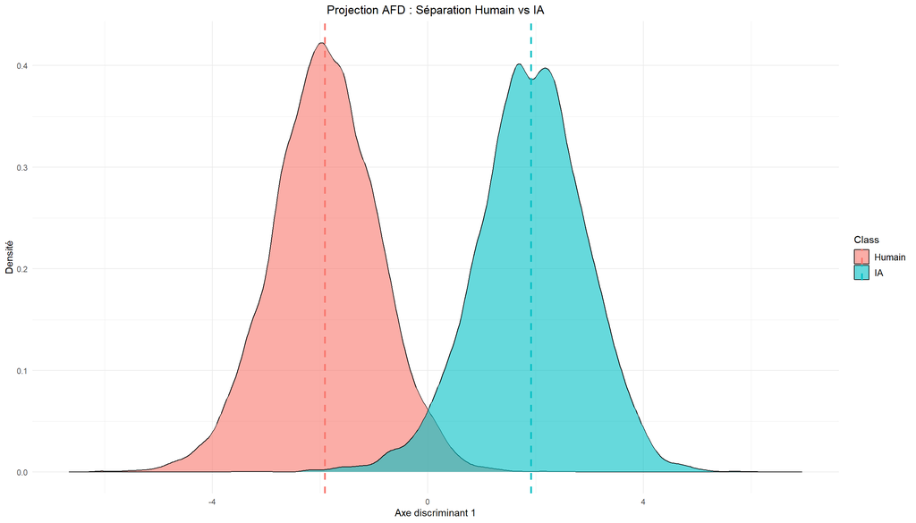

```r
# On utilise le premier axe car on est dans un problème binaire
plot_data_gg <- data.frame(
  LD1 = lda_scores[, 1],
  Class = y
)

# On calcule les centres de gravité de chaque classe
centers <- aggregate(LD1 ~ Class, data = plot_data_gg, mean)

ggplot(plot_data_gg, aes(x = LD1, fill = Class)) +
  geom_density(alpha = 0.6, color = "black") +
  geom_vline(data = centers, aes(xintercept = LD1, color = Class),
             size = 1, linetype = "dashed") +
  theme_minimal() +
  ggtitle("Projection AFD : Séparation Humain vs IA") +
  xlab("Axe discriminant 1") +
  ylab("Densité") +
  theme(
    legend.position = "right",
    legend.text = element_text(size = 10),
    legend.title = element_text(size = 11),
    plot.title = element_text(size = 13, hjust = 0.5),
    axis.title = element_text(size = 11)
  )
```

Sur le graphique obtenu on peut observer deux “montagnes”, on remarque qu’il y a un chevauchement c’est l’endroit où notre modèle va faire des erreurs de confusion.

Pour ce qui est du test de Wilks, on remarque qu’on obtient une valeur propre élevée, ce qui montre que l’axe LD1 explique bien la différence entre nos deux groupes. Le Wilks Lambda est très petit cela montre que les variables choisies sont pertinentes pour classer les textes. La p-value est très petite aussi cela prouve que nos résultats ne sont pas dus au hasard.

### 5. Classification Bayésienne Naïve

Nous allons maintenant appliquer un classifieur Bayésien Naïf sur les axes factoriels que nous a fournis l’AFD. Cette approche est particulièrement efficace car nous allons combiner AFD et Bayésien naïf. Cette combinaison va nous permettre de réduire la dimensionnalité tout en préservant les informations discriminantes (AFD). De plus, les axes de l’AFD sont orthogonaux, ainsi on respecte l’hypothèse d’indépendance du Bayésien naïf. Enfin, étant donné que nous nous situons dans un problème binaire, cette combinaison est très facilement interprétable.

Maintenant nous allons utiliser la **validation croisée en 10 blocs** pour évaluer notre modèle.

```r
df_lda$generated <- as.factor(df_lda$generated)

# D'abord on renomme les catégories pour éviter des erreurs
levels(df_lda$generated) <- make.names(levels(df_lda$generated))

set.seed(123)
train_control <- trainControl(
  method = "cv",
  number = 10,
  savePredictions = "final",
  classProbs = TRUE
)

model_cv <- train(
  generated ~ .,
  data = df_lda,
  method = "naive_bayes",
  trControl = train_control
)

print(model_cv)
```

```
## Naive Bayes
##
## 20000 samples
##     1 predictor
##     2 classes: 'Humain', 'IA'
##
## No pre-processing
## Resampling: Cross-Validated (10 fold)
## Summary of sample sizes: 18000, 18000, 18000, 18000, 18000, 18000, ...
## Resampling results across tuning parameters:
##
##   usekernel  Accuracy  Kappa
##   FALSE      0.97020   0.9404
##    TRUE      0.96995   0.9399
##
## Tuning parameter 'laplace' was held constant at a value of 0
## Tuning
##  parameter 'adjust' was held constant at a value of 1
## Accuracy was used to select the optimal model using the largest value.
## The final values used for the model were laplace = 0, usekernel = FALSE
##  and adjust = 1.
```

#### 5.1 Évaluation des performances

Une fois que le modèle a bien été entraîné sur les 10 blocs, nous pouvons examiner les résultats moyens en particulier l’**Accuracy** qui nous indique le pourcentage de textes correctement classifiés et le **Kappa** qui va prendre en compte le hasard pour rendre l’évaluation plus fiable.

```r
cv_accuracy <- max(model_cv$results$Accuracy)
cv_kappa <- model_cv$results$Kappa[which.max(model_cv$results$Accuracy)]

metrics <- data.frame(
  Mesure = c("Accuracy", "Kappa (CV 10-fold)"),
  Valeur = c(
    paste0(round(cv_accuracy * 100, 2), " %"),
    round(cv_kappa, 3)
  )
)

kable(metrics, caption = "Performance du Modèle Bayésien (Validation Croisée)") %>%
  kable_styling(bootstrap_options = "striped", full_width = F, position = "center")
```

Performance du Modèle Bayésien (Validation Croisée)

| Mesure | Valeur |
| --- | --- |
| Accuracy | 97.02 % |
| Kappa (CV 10-fold) | 0.94 |

- **Matrice de Confusion :**

```r
cv_predictions <- model_cv$pred

# Filtrer les prédictions finales
if (nrow(cv_predictions) > 0) {
  final_preds <- cv_predictions[cv_predictions$Resample != "Resample", ]

  # Vérifier qu'on a des prédictions
  if (nrow(final_preds) > 0) {
    cm_cv <- confusionMatrix(final_preds$pred, final_preds$obs)

    kable(cm_cv$table, caption = "Matrice de Confusion (Validation Croisée)") %>%
      kable_styling(bootstrap_options = c("striped", "hover", "condensed"), full_width = F, position = "center")
  } else {
    cat("Aucune prédiction à afficher\n")
  }
} else {
  cat("Aucune prédiction disponible\n")
}
```

Matrice de Confusion (Validation Croisée)

|  | Humain | IA |
| --- | --- | --- |
| Humain | 9726 | 322 |
| IA | 274 | 9678 |

- **Métriques détaillées par classe :**

```r
if (!is.null(cm_cv$byClass)) {
  class_metrics <- cm_cv$byClass
  detailed_metrics <- data.frame(
    Métrique = names(class_metrics),
    Valeur = round(class_metrics, 4)
  )

  kable(detailed_metrics, caption = "Métriques détaillées de performance") %>%
    kable_styling(bootstrap_options = c("striped", "hover", "condensed"), full_width = F, position = "center")
} else {
  cat("Métriques détaillées non disponibles pour ce modèle\n")
}
```

Métriques détaillées de performance

|  | Métrique | Valeur |
| --- | --- | --- |
| Sensitivity | Sensitivity | 0.9726 |
| Specificity | Specificity | 0.9678 |
| Pos Pred Value | Pos Pred Value | 0.9680 |
| Neg Pred Value | Neg Pred Value | 0.9725 |
| Precision | Precision | 0.9680 |
| Recall | Recall | 0.9726 |
| F1 | F1 | 0.9703 |
| Prevalence | Prevalence | 0.5000 |
| Detection Rate | Detection Rate | 0.4863 |
| Detection Prevalence | Detection Prevalence | 0.5024 |
| Balanced Accuracy | Balanced Accuracy | 0.9702 |

- **Performance par classe :**

```r
if (exists("cm_cv") && !is.null(cm_cv)) {
  # Table de performance par classe
  class_performance <- data.frame(
    Classe = rownames(cm_cv$table),
    Prédictions_Correctes = diag(cm_cv$table),
    Total = rowSums(cm_cv$table)
  )
  class_performance$Taux_Reussite <- round(class_performance$Prédictions_Correctes / class_performance$Total * 100, 2)

  kable(class_performance, caption = "Taux de réussite par classe") %>%
    kable_styling(bootstrap_options = c("striped", "hover"), full_width = F, position = "center")
} else {
  cat("Performance par classe non disponible\n")
}
```

Taux de réussite par classe

|  | Classe | Prédictions_Correctes | Total | Taux_Reussite |
| --- | --- | --- | --- | --- |
| Humain | Humain | 9726 | 10048 | 96.80 |
| IA | IA | 9678 | 9952 | 97.25 |

- **Visualisation des résultats :**

[figure not shown]

```r
if (exists("cm_cv") && !is.null(cm_cv)) {
  # On prépare les données pour la visualisation
  cm_data <- as.data.frame(cm_cv$table)
  colnames(cm_data) <- c("Observé", "Prédit", "Fréquence")

  # Graphique de la matrice de confusion
  ggplot(cm_data, aes(x = Prédit, y = Observé, fill = Fréquence)) +
    geom_tile(color = "black", size = 0.5) +
    geom_text(aes(label = Fréquence), vjust = 0.5, hjust = 0.5, size = 4, fontface = "bold") +
    scale_fill_gradient(low = "white", high = "steelblue") +
    theme_minimal() +
    theme(
      axis.title = element_text(size = 12, face = "bold"),
      plot.title = element_text(size = 13, hjust = 0.5, face = "bold"),
      axis.text = element_text(size = 11)
    ) +
    ggtitle("Matrice de Confusion - Prédictions du modèle Bayésien") +
    xlab("Classe Prédite") +
    ylab("Classe Observée")
} else {
  cat("Matrice de confusion non disponible\n")
}
```

- **Résumé des résultats :**

```r
cat("Nombre total de textes traités :", nrow(df_lda), "\n")
```

```
## Nombre total de textes traités : 20000
```

```r
cat("Nombre de classes (binaire) : 2 (Humain vs IA)\n")
```

```
## Nombre de classes (binaire) : 2 (Humain vs IA)
```

```r
cat("Nombre de features après sélection :", ncol(tfidf_data_reduced), "\n")
```

```
## Nombre de features après sélection : 500
```

```r
cat("Nombre d'axes discriminants :", ncol(df_lda) - 1, "\n\n")
```

```
## Nombre d'axes discriminants : 1
```

- **Performance globale :**

```r
cat("Accuracy globale :", round(cv_accuracy * 100, 2), "%\n")
```

```
## Accuracy globale : 97.02 %
```

```r
cat("Kappa :", round(cv_kappa, 3), "\n\n")
```

```
## Kappa : 0.94
```

```r
if (exists("class_performance") && nrow(class_performance) > 0) {
  cat("--- PERFORMANCE PAR CLASSE ---\n")
  cat("Humain : ", class_performance$Taux_Reussite[1], "%\n")
  cat("IA : ", class_performance$Taux_Reussite[2], "%\n\n")
}
```

```
## --- PERFORMANCE PAR CLASSE ---
## Humain :  96.8 %
## IA :  97.25 %
```

```r
if (exists("cm_cv") && !is.null(cm_cv)) {
  cat("Vrais Positifs (IA correctement détectées) :", cm_cv$table[2,2], "\n")
  cat("Faux Positifs (Humain classifiés comme IA) :", cm_cv$table[1,2], "\n")
  cat("Vrais Négatifs (Humain correctement détectés) :", cm_cv$table[1,1], "\n")
  cat("Faux Négatifs (IA classifiées comme Humain) :", cm_cv$table[2,1], "\n")
}
```

[output not shown]

Les résultats obtenus après la validation croisée sont très bons. On obtient une précision de 97.02% notre modèle réussit à classer presque parfaitement les textes. Le coefficient Kappa de 0.94 confirme que ce n’est pas dû à du hasard. Cela montre que la combinaison entre l’AFD qui permet de simplifier les données et le classifieur Bayésien fonctionnent très bien ensemble pour ce genre de projet.

### 6. Conclusion

Ce projet nous a permis de développer un modèle permettant de distinguer les textes générés par une IA de ceux écrit par des humains.

Tout d’abord, nous avons effectué un prétraitement des données, en nettoyant les textes et en augmentant notre jeu de données pour atteindre un équilibre entre les classes. Ensuite, nous avons extrait des caractéristiques à partir des textes en utilisant la vectorisation TF-IDF, ce qui nous a permis de transformer les textes en données numériques exploitables pour nos modèles. Nous avons ensuite appliqué l’Analyse Factorielle Discriminante (AFD) pour réduire la dimensionnalité tout en préservant les informations importantes, ce qui nous a permis d’identifier les axes qui séparent au mieux les textes humains des textes générés par l’IA.  
Enfin, nous avons utilisé un classifieur Bayésien Naïf sur les axes de l’AFD, avec validation croisée en 10 blocs pour évaluer la performance du modèle.

**Conclusions finales :**

Même si les résultats sont excellents, il faut rester sceptique car les modèles de langages évoluent constamment dans le but d’imiter le style humain. On peut aussi penser que si les résultats sont excellents ca peut être du au fait que les textes de notre jeu de données proviennent de modèles d’IA spécifiques. Peut être que dans un scénario réel avec plusieurs modèle d’IA différentes l’efficacité de notre modèle baisserait un peu.

Cependant pour l’instant grâce à ce projet on a pu montrer que l’IA laissait des “traces” qu’il est encore possible de capturer. Cependant plus on va avancer dans le temps et plus la détection sera compliquée et restera un défi technologique dans les années à venir.